# LAB03-Markdown-Report

НКАбд-03-24

1032238132@pfur.ru

# Титульный лист

**Дисциплина:** Операционные системы  
**Работа:** Лабораторная работа №3 — *Markdown*  
**Студент:** <Кази Ар Рафи, HKA-03-24>

# Введение

**Цель работы** — оформить отчёт в **Markdown**, применить заголовки, списки, ссылки, код, формулы, кросс-ссылки и собрать отчёт в **PDF** и **DOCX** с помощью **Pandoc** и **Makefile**.

**Задачи:** 1. Подготовить отчёт по предыдущей лабораторной работе в формате Markdown.  
2. Продемонстрировать основные элементы разметки.  
3. Вставить скриншоты выполнения (с подписями и кросс-ссылками).  
4. Настроить сборку в форматы PDF и DOCX.

# Формулировка задания

Оформить отчёт по предыдущей лабораторной работе в формате **Markdown** и предоставить его в форматах **MD, PDF, DOCX** в архиве со скриншотами и Makefile.

# Основная часть

## 1. Заголовки

```
# Заголовок 1
## Заголовок 2
### Заголовок 3
#### Заголовок 4
```

## 2. Выделение текста

- **Жирный**, *курсив*, **жирный+курсив**.

## 3. Цитаты

> Пример цитаты.

## 4. Списки

Маркированный:

- Пункт 1
- Пункт 2
  - Подпункт A
  - Подпункт B

Нумерованный:

1. Шаг 1
   1. Подшаг 1.1
   1. Подшаг 1.2
1. Шаг 2

## 5. Ссылки

[Официальный сайт Pandoc](https://pandoc.org/)

## 6. Код

Встроенный `код` и блок:

```
pandoc LAB03-Markdown-Report.md -o LAB03-Markdown-Report.pdf
```

## 7. Индексы и формулы

Примеры индексов: H<sub>2</sub>O, 2<sup>10</sup>.

Формулы:

Встроенная: sin<sup>2</sup>(*x*) + cos<sup>2</sup>(*x*) = 1.

## 8. Скриншоты выполнения

**Скриншот 1 — запуск команды**

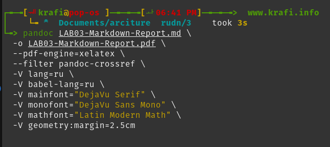

**Скриншот 2 — конфигурация**

[figure not shown]

**Скриншот 3 — итоговый вывод**

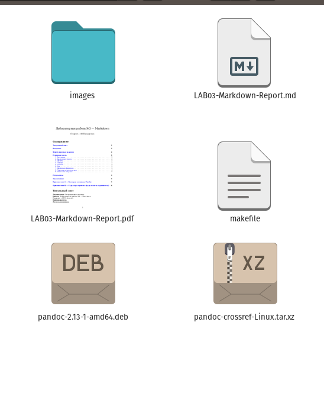

## 9. Ответы на вопросы

1. **Вопрос 1:** Что такое Markdown?  
   **Ответ:** Markdown — это облегченный язык разметки с простым синтаксисом, который преобразуется в HTML. Он используется для форматирования текста (жирный, курсив, заголовки, списки) без сложных тегов.
1. **Вопрос 2:** Для чего нужен Makefile?  
   **Ответ:** Makefile — это файл, содержащий инструкции для утилиты `make`. Он автоматизирует сборку проектов, компиляцию кода, генерацию документов и другие задачи, определяя зависимости и команды.
1. **Вопрос 3:** Что делает Pandoc?  
   **Ответ:** Pandoc — это универсальный конвертер документов. Он преобразует файлы между форматами (например, Markdown → PDF, HTML → DOCX) с поддержкой стилей и метаданных.

# Результаты

# Заключение

Цель выполнена: отчёт оформлен в Markdown и собран в требуемые форматы.

# Приложение A — Быстрые команды Pandoc

```
# MD -> PDF
pandoc LAB03-Markdown-Report.md -o LAB03-Markdown-Report.pdf --filter pandoc-crossref --pdf-engine=xelatex -V mainfont="DejaVu Serif" -V geometry:margin=2.5cm

# MD -> DOCX
pandoc LAB03-Markdown-Report.md -o LAB03-Markdown-Report.docx --filter pandoc-crossref
```

# Приложение B — Структура проекта (куда класть скриншоты)

```
lab03-markdown/
├─ LAB03-Markdown-Report.md
├─ Makefile
├─ images/
│  ├─ step1.png   ← сюда положите первый скриншот
│  ├─ step2.png   ← сюда второй
│  ├─ step3.png   ← сюда третий
│  └─ ...
```